# PSY4210: My First Quarto File

Author

Joshua F. Wiley

Published

February 19, 2026

Download the raw `R` code here: https://jwiley.github.io/MonashHonoursStatistics/MyFirstQuarto.qmd.

# 1 Quarto Files

Quarto files can combine `R` code for data analysis with markdown, a markup language that adds some additional text to plain text to manage formating. More information is here: https://quarto.org/.

For example, asterisks can be used around words to *italicize* the words, or double asterisks to **make words bold**. Hashtags create headings, with one, two, three, etc. hashtags creating:

# 2 Level 1 Heading

## 2.1 Level 2 Heading

### 2.1.1 Level 3 Heading

The benefit of `R` and markdown together is that you can write `R` code and in between your code, you can write regular text in markdown to explain what the code does or interpret the output. To let the computer know some of what we type is `R` code, we delimitters that indicate the start and end of `R` code: triple backticks and `r`. Here is our first `R` code chunk, where we ask `R` to calculate 6 * 5.5. In the markdown part, nothing happens, but when written as `R` code it can be processed and `R` will work as a calculator.

```r
6 * 5.5
```

```
[1] 33
```

The whole set of `R` code above is called a “chunk” and any document can have none, one or more `R` code chunks. Inside the curly braces that start each chunk, we can write additional code to give the chunk a name and control other aspects of how it is run. For example, let’s call the next chunk “TestName” and there let’s find out the homework mark if someone did 14 of the chapters and 4 of the courses from the homework software exercises.

```r
14 * (1/46) + 4 * (4/46)
```

```
[1] 0.6521739
```

# 3 Using `R` Packages

We often want to do more data analysis or use tools that are not part of “default” `R`. There are many packages (like apps for a phone) that augment `R`. In fact there are over 10,000 such packages. The [setuppage](http://joshuawiley.com/MonashHonoursStatistics/IntroR.html) linked in Week 1 for Moodle had you install several of these. In our first `R` markdown file, let’s just use two important ones:

- `data.table` is a package with extensive data management tools
- `ggplot2` is the second version of the **g**rammar of **g**raphics plot package. It makes amazing graphs in `R` and we’ll rely on it for data visualization.

To open a package (app), instead of tapping like a phone, we use the `library()` function. In `R` functions always have a name and then an open and close paretheses. We add arguments or options inside the parentheses to tell the funciton what we want it to do specifically. The `library()` function is used to access our library of packages and open a specific one, and the argument we need to give it is the name. Here is an example.

```r
## open the data.table app for data management
library(data.table)

## open the ggplot2 app for graphing
library(ggplot2)
```

In the `R` chunk above, you might have noticed that hash tags were used, but they did not make level 2 headings. Inside an `R` chunk, what we write behaves *differently* to outside and `R` chunk. In `R` hashtags indicate that everything that follows on that line is a comment. That is, its not actually code, its just a short note or comment to ourselves or our reader about what this code is supposed to do. Now, let’s do a few simple things with a dataset. First, we’ll convert the built in `mtcars` dataset with different features of 32 cars into a `data.table` and we’ll call it “d” (formally, we assign the results of the function call to an object, “d”). That means when we type “d” in the future, in `R` that will mean the data.table of the mtcars data. Then we’ll look at a few rows of the data, and view only the rows that correspond to cars that get over 30 miles per gallon (this is an old dataset).

```r
## convert mtcars dataset to a data.table
d <- as.data.table(mtcars)

## view the first few rows of the data
head(d)
```

```
     mpg   cyl  disp    hp  drat    wt  qsec    vs    am  gear  carb
   <num> <num> <num> <num> <num> <num> <num> <num> <num> <num> <num>
1:  21.0     6   160   110  3.90 2.620 16.46     0     1     4     4
2:  21.0     6   160   110  3.90 2.875 17.02     0     1     4     4
3:  22.8     4   108    93  3.85 2.320 18.61     1     1     4     1
4:  21.4     6   258   110  3.08 3.215 19.44     1     0     3     1
5:  18.7     8   360   175  3.15 3.440 17.02     0     0     3     2
6:  18.1     6   225   105  2.76 3.460 20.22     1     0     3     1
```

```r
## view only cars that get over 30 mpg
d[mpg > 30]
```

```
     mpg   cyl  disp    hp  drat    wt  qsec    vs    am  gear  carb
   <num> <num> <num> <num> <num> <num> <num> <num> <num> <num> <num>
1:  32.4     4  78.7    66  4.08 2.200 19.47     1     1     4     1
2:  30.4     4  75.7    52  4.93 1.615 18.52     1     1     4     2
3:  33.9     4  71.1    65  4.22 1.835 19.90     1     1     4     1
4:  30.4     4  95.1   113  3.77 1.513 16.90     1     1     5     2
```

Finally, let’s take a look at a couple basic graphs using `ggplot2`. We’ll cover how to create graphs and visualize data in more depth later, for now, just focus on how to run `R` code and where the code, output and explanation live in an `R` markdown file.

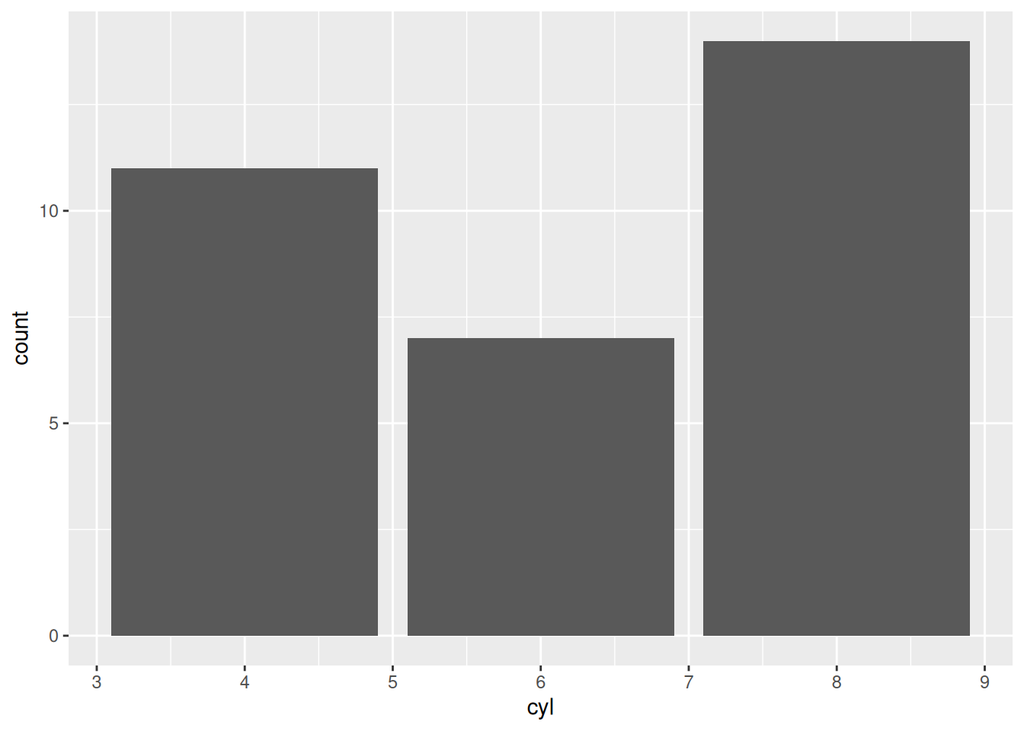

```r
## bar plot
ggplot(d, aes(cyl)) +
  geom_bar()
```

Sometimes, we might want to adjust the size of the graph. We can do this through *chunk options* which are addded in the header of the chunk.

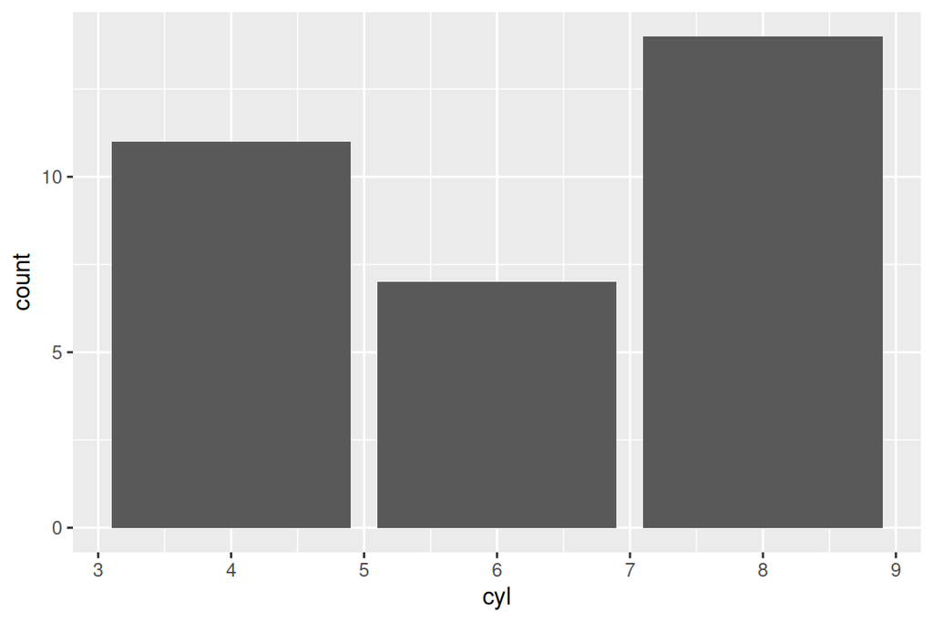

```r
## bar plot
ggplot(d, aes(cyl)) +
  geom_bar()
```

The very last step is to turn all of this code into a document that you can reference later or could send to someone else. This is one of the great parts of using Quarto files. You may do some analysis now and need to refer to it later, or you may do some analysis and want to send it to a coworker who knows nothing about `R` but you still want them to see all yours notes and all the output. We’ll do this by `render`ing the Quarto file. You can do this through code, but we’ll use `RStudio` or `Positron` to help us do it.